# TP2new

# TP2-LP Data Mining

On va dans un premier temps charger les packages nécéssaires pour le TP. Attention, il faut éventuellement les installer au prélable. Les graphiques seront réalisés avec la fonction ggplot.

```r
library(ggplot2)
library(readxl)
library(knitr)
library(reshape2)
```

## Exercice 1

Dans cet exercice, on va travailler sur les résultats d’un questionnaire adressé à des médecins généralistes et portant sur l’insuffisance veineuse chronique (IVC). Les résultats de ce questionnaire sont donnés dans tableau de données IVC.xlxs. On ne va travailler que sur une partie des réponses. On va charger le jeu de données avec la fonction excel_sheet du package readxl.

```r
sheet_names <- excel_sheets("~\\R-Folder\\S1\\TP2\\IVC.xlsx")
```

## Partie 1

Dans un premiers, on ne s’intéresse qu’aux données du premier onglet (données épidémiologiques) qui renseigne le profil des médecins ayant répondu au questionnaire. Pour cela, on effectue la commande

```r
donneesEpidemio <- read_excel("~\\R-Folder\\S1\\TP2\\IVC.xlsx",sheet = 1)
```

```
## * `` -> ...1
```

Puis, on retire les lignes vides

```r
donneesEpidemio <- na.omit(donneesEpidemio)
```

Voici un aperçu du tableau de données

```r
str(donneesEpidemio)
```

```
## tibble [158 x 9] (S3: tbl_df/tbl/data.frame)
##  $ ...1                  : num [1:158] 1 2 3 4 5 6 7 8 9 10 ...
##  $ sexe                  : chr [1:158] "F" "M" "F" "M" ...
##  $ âge                   : chr [1:158] "<45 ans" ">54 ans" "Entre 46 et 54 ans" ">54 ans" ...
##  $ contexte exercice     : chr [1:158] "rural" "rural" "urbain" "rural" ...
##  $ type exercice         : chr [1:158] "groupe" "seul" "seul" "groupe" ...
##  $ durée exercice        : chr [1:158] "<10 ans" ">30 ans" "Entre 10 et 30 ans" ">30 ans" ...
##  $ departement           : chr [1:158] "Oise" "Somme" "Oise" "Somme" ...
##  $ diplôme complémentaire: chr [1:158] "Aucun" "Médecine sport, gériatrie" "Acupuncture, homéopathie, douleur, nutrition" "Aucun" ...
##  $ MSU                   : chr [1:158] "Non" "Non" "Non" "Non" ...
##  - attr(*, "na.action")= 'omit' Named int [1:342] 159 160 161 162 163 164 165 166 167 168 ...
##   ..- attr(*, "names")= chr [1:342] "159" "160" "161" "162" ...
```

On peut remarquer que les données ne sont pas au format data.frame mais au format tibble. On ne va pas travailler directement avec ce format (on pourrait aussi). On va le transformer en objet data.frame.

```r
class(donneesEpidemio)
```

```
## [1] "tbl_df"     "tbl"        "data.frame"
```

```r
dataTemp <- data.frame(donneesEpidemio)
class(dataTemp)
```

```
## [1] "data.frame"
```

On va également supprimer la première colonne qui ne renseigne que les numéros des individus

```r
dataTemp <- dataTemp[,-1]
```

On pourra noter que MSU signifie Maître de stage universitaire. ## 1. Quelle est la dimension du tableau ?

```r
#Pour afficher les dimensions du tableau on utilise la commande dim()
dim(dataTemp)
```

```
## [1] 158   8
```

On observe ici que le tableau est composé de 8 colonnes et 158 lignes.

## 2. Décrire les variables du jeu de données. On renseignera en particulier leur nature.

En regardant le jeu de données on observe que les variables sont de type qualitatives.

## 3. On donnera également des descriptifs numériques et visuels de ces variables.

```r
#Il est dans un premier temps nécessaire de transformer nos variables en factor pour faire des opérations dessus.
sexe = as.factor(dataTemp$sexe)
age = as.factor(dataTemp$âge)
contexte.exercice= as.factor(dataTemp$contexte.exercice)
type.exercice = as.factor(dataTemp$type.exercice)
duree.exercice = as.factor(dataTemp$durée.exercice)
departement = as.factor(dataTemp$departement)
diplome = as.factor(dataTemp$diplôme.complémentaire)
MSU = as.factor(dataTemp$MSU)
```

###Pour obtenir des résultats numérique on utilise les tables de contingence :

```r
table(sexe)
table(age)
table(contexte.exercice)
table(type.exercice)
table(duree.exercice)
table(departement)
table(diplome)
table(MSU)
```

[output not shown]

A l’aide de ces tables on peut obtenir des informations en utilisant diverses commandes, par exemple la moyenne d’homme médecin.

```r
mean(sexe=='M')
```

```
## [1] 0.6329114
```

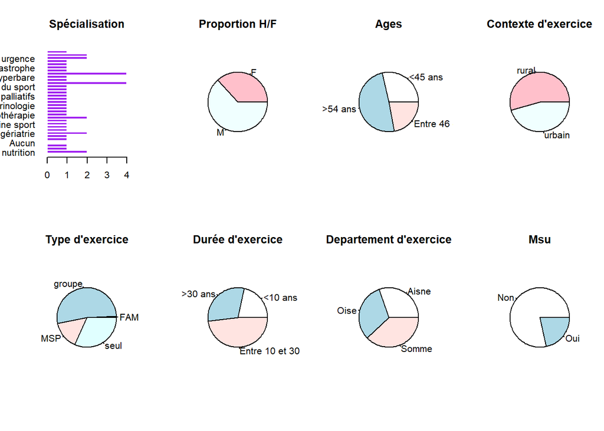

```r
par(mfrow = c(2, 4))
barplot(table(diplome[!diplome=="Aucun"]), horiz=TRUE, las=1, col= "purple", border = "white",main= "Spécialisation") # on retire les médecins sans spécialisation pour une meilleure lecture du graphique
pie(table(sexe), col = c("pink","azure"), main = "Proportion H/F")
pie(table(age), main= "Ages")
pie(table(contexte.exercice), col = c("pink","azure"), main= "Contexte d'exercice")
pie(table(type.exercice), main = "Type d'exercice")
pie(table(duree.exercice), main = "Durée d'exercice")
pie(table(departement),main = "Departement d'exercice")
pie(table(MSU),main= "Msu")
```

##4. Dans quelle région le questionnaire a-t-il été réalisé ?

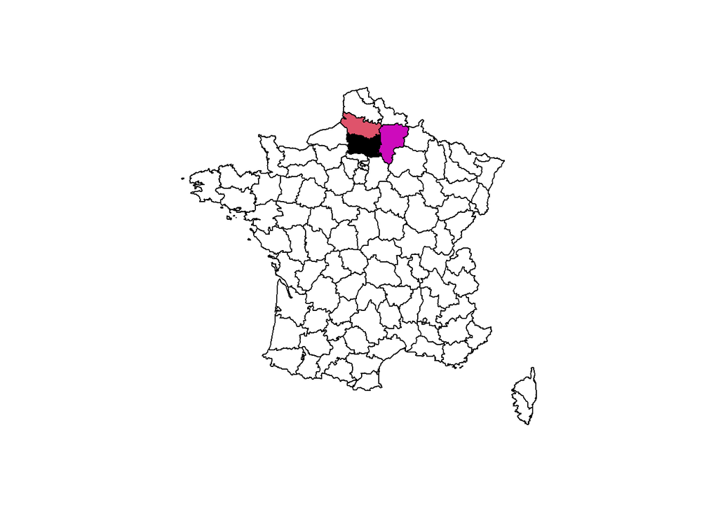

```r
map(database="france", fill=TRUE, col=color)
```

On observe que les départements en colorés correspondent à la région Picardie, c’est ici que le questionnaire a été réalisé.

## 5. À l’aide de descriptif visuels et numériques, décrire les intéractions entre la variable département et contexte d’exercice, âge et contexte d’exercice, âge et sexe et âge et diplôme complémentaire.

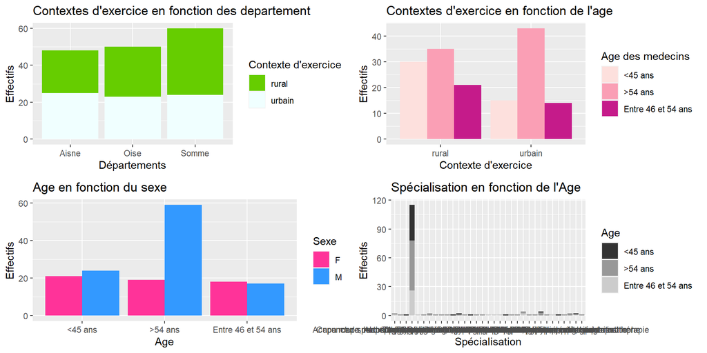

```r
#install.packages("cowplot")
library(cowplot)
plot_grid(graph,graph2,graph3,graph4, align = "hV")
```

```r
#install.packages("knitr")
library(knitr)
t1= table(departement,contexte.exercice)
t2= table(age,contexte.exercice)
t3= table(age,sexe)
t4= table(diplome,age)
```

Les contextes d’exercice en fonction du département

|  | rural | urbain |
| --- | --- | --- |
| Aisne | 23 | 25 |
| Oise | 27 | 23 |
| Somme | 36 | 24 |

Les contextes d’exercice en fonction de l’age des practiciens

|  | rural | urbain |
| --- | --- | --- |
| <45 ans | 30 | 15 |
| >54 ans | 35 | 43 |
| Entre 46 et 54 ans | 21 | 14 |

Les ages en fonction du sexe des practiciens

|  | F | M |
| --- | --- | --- |
| <45 ans | 21 | 24 |
| >54 ans | 19 | 59 |
| Entre 46 et 54 ans | 18 | 17 |

Les spécialisation en fonction de l’age des practiciens

|  | <45 ans | >54 ans | Entre 46 et 54 ans |
| --- | --- | --- | --- |
| Acupuncture, homéopathie, douleur, nutrition | 0 | 1 | 1 |
| Alcoologie, nutrition | 0 | 1 | 0 |
| Angiologie | 1 | 0 | 0 |
| Aucun | 37 | 52 | 26 |
| capa med sport + gériatrie + DU soins pal | 0 | 0 | 1 |
| Capa med sport + urg + voyage + gériatrie ; DU pharmaco | 0 | 1 | 0 |

##6. Décrire succintement les résultats obtenus. En Picardie, seul le département de l’Ainse comporte plus de médecins pratiquant en milieu urbain qu’en milieu rural. Dans la Somme et l’Oise, la majorité des médecins pratiquent dans un cadre rural.

## 7. Quelle est le pourcentage, au sein de l’échantillon, de praticiens qui exercent seuls.

```r
seul = c(which(dataTemp$type.exercice== "seul"))
length(seul)/length(dataTemp$type.exercice)*100
```

```
## [1] 31.64557
```

31.6% des praticiens exercent seuls leur métier.

## 8. Donner le pourcentage, au sein de l’échantillon, de praticiens de moins de 45 ans qui exercent depuis moins de 10 ans.

```r
nb_45_et_10 <- which(age=="<45 ans" & duree.exercice == "<10 ans")
 # 32 médecins <45 ans et durée <10ans
length(nb_45_et_10)/length(dataTemp$type.exercice)*100
```

```
## [1] 20.25316
```

Les practitiens de moins de 45 ans qui exercent depuis moins de 10 ans représentent 20.2% de l’échantillon. ## 9. Donner le pourcentage, au sein de l’échantillon, de praticiens de plus de 54 ans qui exercent dans la Somme.

```r
S54 = c(which(dataTemp$departement== "Somme" & dataTemp$âge== ">54 ans"))
length(S54)/length(dataTemp$âge)* 100
```

```
## [1] 16.4557
```

Les practiciens de plus de 54 ans qui exercent dans la Somme represente 16,45% de l’echantillion.

# Partie 2

Dans une deuxième partie, on va travailler sur les résultats des questions 1, 3 et 5 dont les intitulés sont les suivant • Question 1: Vous arrive-t-il d’aborder le sujet de l’insuffisance veineuse lors d’une consultation alors même qu’il ne s’agit pas du motif principal de consultation ? • Question 3: Quels sont les 3 principaux motifs de consultation d’IVC de vos patients ? • Question 5: Quels sont les trois signes cliniques les plus évocateurs d’IVC ? Pour charger les réponses de la question 1, on effectue la commande

```r
question1 <- read_excel("~\\R-Folder\\S1\\TP2\\IVC.xlsx",sheet = 2)
```

```
## * `` -> ...1
```

## 1. Selon les réponses des praticiens, quels sont les trois motifs principaux de consultation ? Expliquer la démarche et donner un descriptif visuel du résultat.

```r
question3 <- read_excel("~\\R-Folder\\S1\\TP2\\IVC.xlsx",sheet = 4)
```

```
## * `` -> ...1
```

```r
question3 = question3[,-1]
question3 = na.omit(question3)

#descriptif numérique
summary(question3)
```

```
##     D, L, I            T, V           Varices         Oedème MI
##  Min.   :0.0000   Min.   :0.0000   Min.   :0.0000   Min.   :0.0000
##  1st Qu.:1.0000   1st Qu.:0.0000   1st Qu.:0.0000   1st Qu.:0.0000
##  Median :1.0000   Median :0.0000   Median :1.0000   Median :1.0000
##  Mean   :0.8734   Mean   :0.2532   Mean   :0.7025   Mean   :0.7089
##  3rd Qu.:1.0000   3rd Qu.:0.7500   3rd Qu.:1.0000   3rd Qu.:1.0000
##  Max.   :1.0000   Max.   :1.0000   Max.   :1.0000   Max.   :1.0000
##  Dermite de stase      Eczéma         Dermite ocre    Atrophie blanche
##  Min.   :0.00000   Min.   :0.00000   Min.   :0.0000   Min.   :0
##  1st Qu.:0.00000   1st Qu.:0.00000   1st Qu.:0.0000   1st Qu.:0
##  Median :0.00000   Median :0.00000   Median :0.0000   Median :0
##  Mean   :0.08861   Mean   :0.07595   Mean   :0.1013   Mean   :0
##  3rd Qu.:0.00000   3rd Qu.:0.00000   3rd Qu.:0.0000   3rd Qu.:0
##  Max.   :1.00000   Max.   :1.00000   Max.   :1.0000   Max.   :0
##  Lipodermatosclérose   Ulcère(s)
##  Min.   :0           Min.   :0.0000
##  1st Qu.:0           1st Qu.:0.0000
##  Median :0           Median :0.0000
##  Mean   :0           Mean   :0.1962
##  3rd Qu.:0           3rd Qu.:0.0000
##  Max.   :0           Max.   :1.0000
```

On regarde ici la médiane, les 3 motifs principaux possèdent une médiale égale 1, on peut aussi regarder les moyennes se rapprochant le plus de 1. Ces signes distinctifs permettent d’identifier les motifs pour lesquels il y a eu le plus de consultations. On peut également vérifier via des tables :

Matrice des consultations

|  | T1 | T2 | T3 | T4 | T5 | T6 | T7 | T10 |
| --- | --- | --- | --- | --- | --- | --- | --- | --- |
| 0 | 20 | 118 | 47 | 46 | 144 | 146 | 142 | 127 |
| 1 | 138 | 40 | 111 | 112 | 14 | 12 | 16 | 31 |

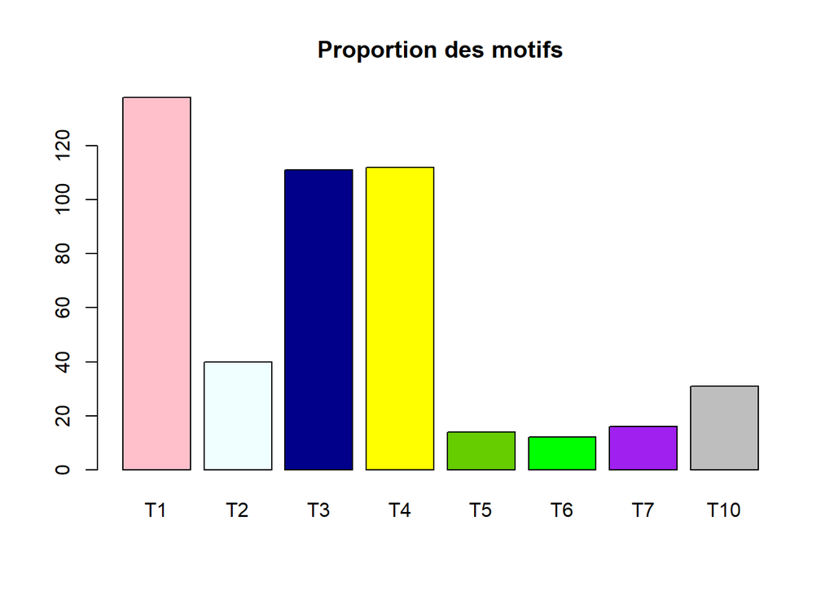

```r
#descriptif visuel
barplot(matrice[2,1:8], col = c("pink","azure","blue4","yellow","chartreuse3","green","purple","grey"), main = "Proportion des motifs")
```